# Laboratório 1 Parte 4, Marcus Vinicius

```r
atividade = read_projectdata()
```

## Existe relação entre a postagem própria mais popular de um parlamentar com seu retweet mais popular?

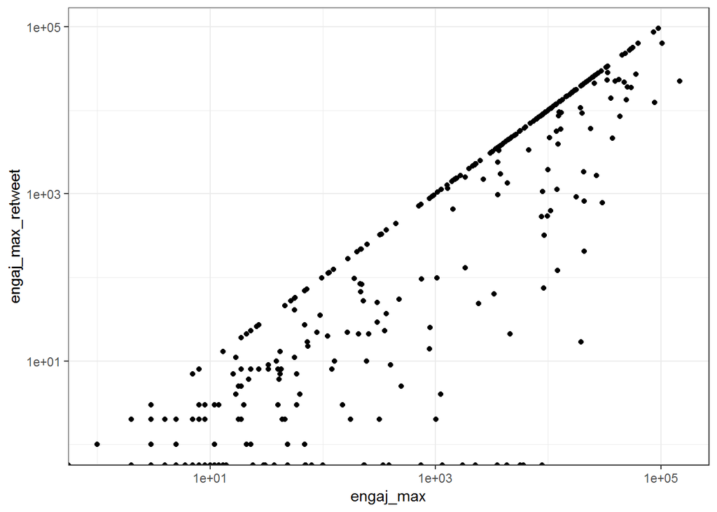

```r
atividade %>% filter(!is.na(seguidores)) %>%
  ggplot(aes(x = engaj_max, y = engaj_max_retweet)) +
  geom_point() + scale_x_log10() +
  scale_y_log10()
```

Ao plotar o gráfico de pontos de ambas as variáveis, podemos perceber que existe uma forte correlação entre elas, muito pelo fato de, o engajamento ser uma variável que evidencia a soma de likes + retweets de uma postagem, e é de se esperar que, para o mesmo parlamentar, o engajamento máximo próprio, ou seja, a postagem mais “famosa” daquele parlamentar esteja associada ao engajamento máximo para um retweet, que nada mais é que o retweet mais “famoso” daquele parlamentar. Essa associação é dedutível pois ambas as postagens abrangem o mesmo público alvo, os seguidores daquele parlamentar, logo, espera-se que seus tweets/retweets mais famosos estejam no mesmo limiar de popularidade.

```r
cor_engaj_max = atividade %>% filter(!is.na(seguidores)) %>% pull(engaj_max )
cor_engaj_max_retweet = atividade %>% filter(!is.na(seguidores)) %>% pull(engaj_max_retweet)

cor(cor_engaj_max, cor_engaj_max_retweet)
```

```
## [1] 0.8444738
```

Usando a função cor, que retorna a correlação entre duas variáveis, podemos evidenciar que ambas possuem uma alta correlação entre si.

## O número de seguidores de um parlamentar está associado a quantas pessoas ele segue?

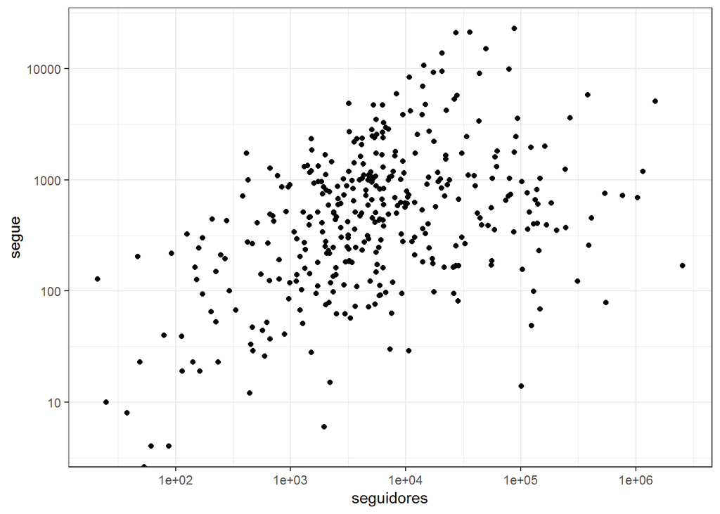

```r
atividade %>% filter(!is.na(seguidores)) %>%
  ggplot(aes(x = seguidores, y = segue)) +
  geom_point()  + scale_x_log10() +
  scale_y_log10()
```

Ao plotar o gráfico de pontos de ambas as variáveis, fica nítido que elas possuem uma correlação extremamente baixa (os pontos estão bastante dispersos). Esse resultado é esperado, já que, é usual os parlamentares possuirem bastante seguidores mas não se preocuparem em seguir outros perfis.

```r
cor_seguidores = atividade %>% filter(!is.na(seguidores)) %>% pull(seguidores)
cor_segue = atividade %>% filter(!is.na(seguidores)) %>% pull(segue)

cor(cor_seguidores, cor_segue)
```

```
## [1] 0.03311237
```

Ao utilizar a função que retorna a correlação entre elas, podemos concluir que sua correlação é bastante fraca, beirando a não existência.